# Big GAM modelling of aggregate electricity demand in the UK: solution

1. Load data and fit a basic Gaussian GAM:

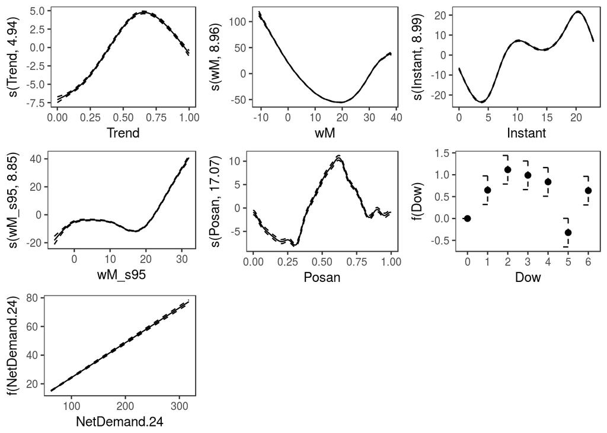

```r
library(mgcViz)
load(paste0(goodLocation, "/data/gefcom_big.rda")) # change this

fit1 <- bamV(NetDemand ~ Dow +
               NetDemand.24 +
               s(Trend, k = 6, bs = "cr") +
               s(wM, bs = "cr") +
               s(Instant, bs = "cr") +
               s(wM_s95, bs = 'cr') +
               s(Posan, bs='cc', k=20),
             data = gefcom_big,
             aGam = list(discrete = TRUE, nthreads = 2),
             aViz = list(nsim = 50))

print(plot(fit1, allTerms = TRUE), pages = 1)
```

2. Check if bases are large enough:

```r
tmp <- check(fit1)
```

```
##
## Method: fREML   Optimizer: perf chol
## $grad
## [1] -9.541257e-13  2.133652e-08 -4.682033e-12  3.455014e-12 -2.328804e-12
## [6] -2.176967e-08
##
## $hess
##            [,1]          [,2]          [,3]          [,4]          [,5]
##    1.9840134092 -0.0001297148 -0.0002313504 -0.0019279437  0.0006264161
##   -0.0001297148  3.9729501142 -0.0007580817  0.0008260341 -0.0001691405
##   -0.0002313504 -0.0007580817  3.9927727172 -0.0003937512 -0.0009272391
##   -0.0019279437  0.0008260341 -0.0003937512  3.8742358160  0.0036112897
##    0.0006264161 -0.0001691405 -0.0009272391  0.0036112897  7.2067539754
## d -1.9675265553 -3.9822748286 -3.9945411780 -3.9265118109 -8.5350981806
##           [,6]
##      -1.967527
##      -3.982275
##      -3.994541
##      -3.926512
##      -8.535098
## d 30258.500000
##
## Model rank =  58 / 58
##
## Basis dimension (k) checking results. Low p-value (k-index<1) may
## indicate that k is too low, especially if edf is close to k'.
##
##               k'   edf k-index p-value
## s(Trend)    5.00  4.94    0.72  <2e-16 ***
## s(wM)       9.00  8.96    0.99   0.175
## s(Instant)  9.00  8.99    1.00   0.660
## s(wM_s95)   9.00  8.85    0.98   0.045 *
## s(Posan)   18.00 17.07    0.82  <2e-16 ***
## ---
## Signif. codes:  0 '***' 0.001 '**' 0.01 '*' 0.05 '.' 0.1 ' ' 1
```

The p-values for `Trend` and `Posan` are very low, suggesting that we should increase the dimension of their spline bases (by increasing `k`). However, if we do this for `Tendance` (which is simply a time counter) we will ultimately end up interpolating the data! Increasing the basis dimension for `Posan` might lead to a similar problem.

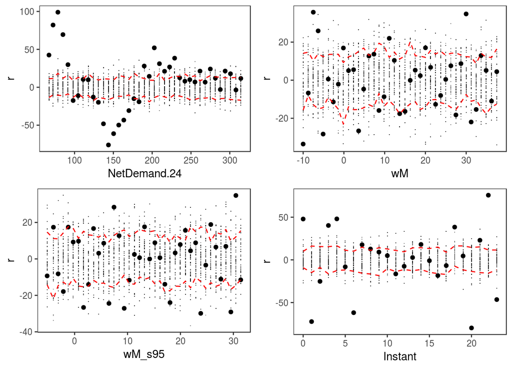

```r
library(gridExtra)
pl <- lapply(c("NetDemand.24", "wM", "wM_s95", "Instant"),
             function(.nam){
               ( check1D(fit1, x = .nam) + l_gridCheck1D(n = 40) )$ggObj
             })

grid.arrange(grobs = pl, ncol = 2)
```

3. Re-fit with larger bases, re-check and look for interactions

```r
fit2 <- bamV(NetDemand ~ Dow +
             s(NetDemand.24, bs = "cr", k = 20) +
             s(Trend, k = 6, bs = "cr") +
             s(wM, bs = "cr", k = 20) +
             s(Instant, bs = "cr", k = 20) +
             s(wM_s95, bs = 'cr', k = 20) +
             s(Posan, bs='cc', k = 30),
           data = gefcom_big,
             aGam = list(discrete = TRUE, nthreads = 2),
             aViz = list(nsim = 50))

tmp <- check(fit2) # Looks better
```

```
##
## Method: fREML   Optimizer: perf chol
## $grad
## [1] -4.183320e-13  2.541434e-11 -4.787282e-12  3.552714e-15 -3.019807e-13
## [6]  6.536993e-13 -3.419700e-10
##
## $hess
##            [,1]          [,2]          [,3]          [,4]         [,5]
##    4.2217356837 -0.0007084397  0.0053379212  0.0077973667 -0.008750155
##   -0.0007084397  1.9846585401  0.0001382416 -0.0005922382 -0.003181208
##    0.0053379212  0.0001382416  5.8911194313 -0.0014294211 -0.049492010
##    0.0077973667 -0.0005922382 -0.0014294211  8.7127280594 -0.001435169
##   -0.0087501547 -0.0031812085 -0.0494920099 -0.0014351692  6.187191418
##    0.0214512654 -0.0017184572  0.0031251755 -0.0030457260 -0.044722652
## d -5.3875299099 -1.9698516301 -8.1753918081 -8.7101849338 -7.464314464
##            [,6]         [,7]
##     0.021451265    -5.387530
##    -0.001718457    -1.969852
##     0.003125176    -8.175392
##    -0.003045726    -8.710185
##    -0.044722652    -7.464314
##     9.065075776   -12.580135
## d -12.580134870 30258.500000
##
## Model rank =  116 / 116
##
## Basis dimension (k) checking results. Low p-value (k-index<1) may
## indicate that k is too low, especially if edf is close to k'.
##
##                    k'   edf k-index p-value
## s(NetDemand.24) 19.00 11.78    1.01    0.72
## s(Trend)         5.00  4.94    0.72  <2e-16 ***
## s(wM)           19.00 17.35    1.01    0.74
## s(Instant)      19.00 18.42    0.99    0.18
## s(wM_s95)       19.00 15.93    1.00    0.37
## s(Posan)        28.00 25.16    0.82  <2e-16 ***
## ---
## Signif. codes:  0 '***' 0.001 '**' 0.01 '*' 0.05 '.' 0.1 ' ' 1
```

EDF now lower then `k'` for all variables, apart from `Tendance` and `Posan` (but this is ok, see above).

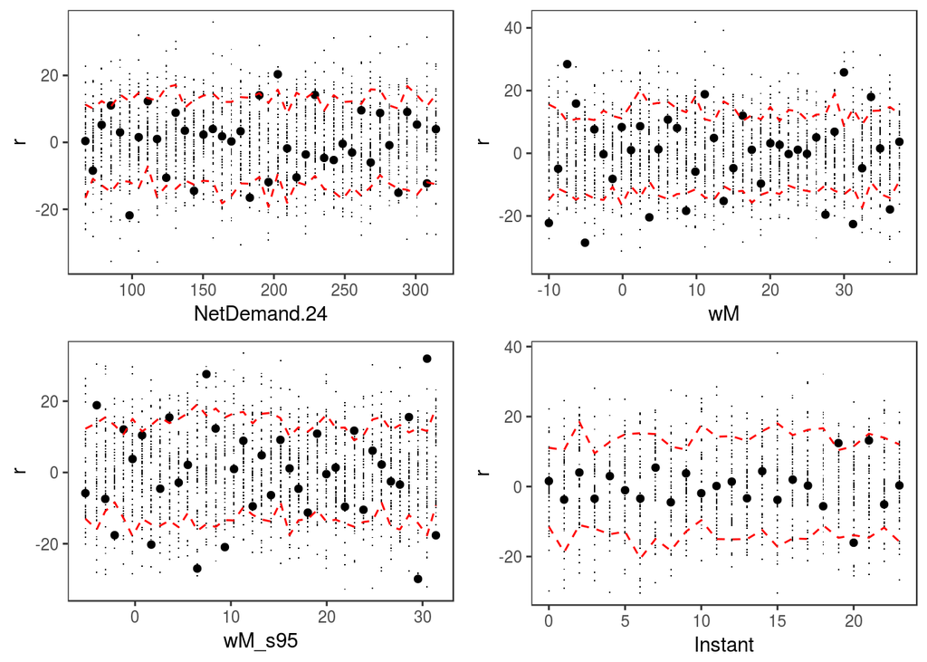

```r
# 1D residuals checks
pl <- lapply(c("NetDemand.24", "wM", "wM_s95", "Instant"),
       function(.nam){
         ( check1D(fit2, x = .nam) + l_gridCheck1D(n = 40) )$ggObj
       })

grid.arrange(grobs = pl, ncol = 2)
```

4. We start by looking for interactions with `Instant`:

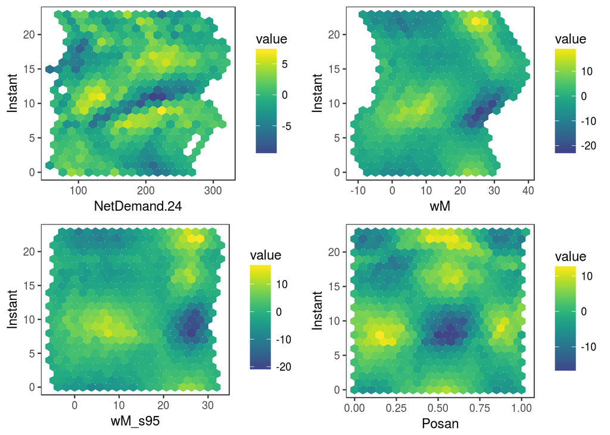

```r
pl <- lapply(c("NetDemand.24", "wM", "wM_s95", "Posan"),
             function(.nam){
               ( check2D(fit2, x1 = .nam, x2 = "Instant") + l_gridCheck2D() )$ggObj
             })

grid.arrange(grobs = pl, ncol = 2)
```

All of plots show systematic patterns: all interactions with `Instant` need to be included.

```r
fit3 <- bamV(NetDemand ~ Dow +
               s(NetDemand.24, bs = "cr", k = 20) +
               s(Trend, k = 6, bs = "cr") +
               s(wM, bs = "cr", k = 20) +
               s(Instant, bs = "cr", k = 20) +
               s(wM_s95, bs = 'cr', k = 20) +
               s(Posan, bs='cc', k=30) +
               ti(NetDemand.24, Instant, k = c(15, 15), bs = c("cr", "cr")) +
               ti(wM, Instant, k = c(10, 10), bs = c("cr", "cr")) +
               ti(wM_s95, Instant, k = c(15, 15), bs = c("cr", "cr")) +
               ti(Posan, Instant, k = c(10, 15), bs = c("cc", "cr")),
             data = gefcom_big,
             aGam = list(discrete = TRUE, nthreads = 2),
             aViz = list(nsim = 50))

AIC(fit2, fit3)
```

```
##            df      AIC
## fit2 102.6823 460416.5
## fit3 485.6651 431580.1
```

Now lets repeat the visual checks

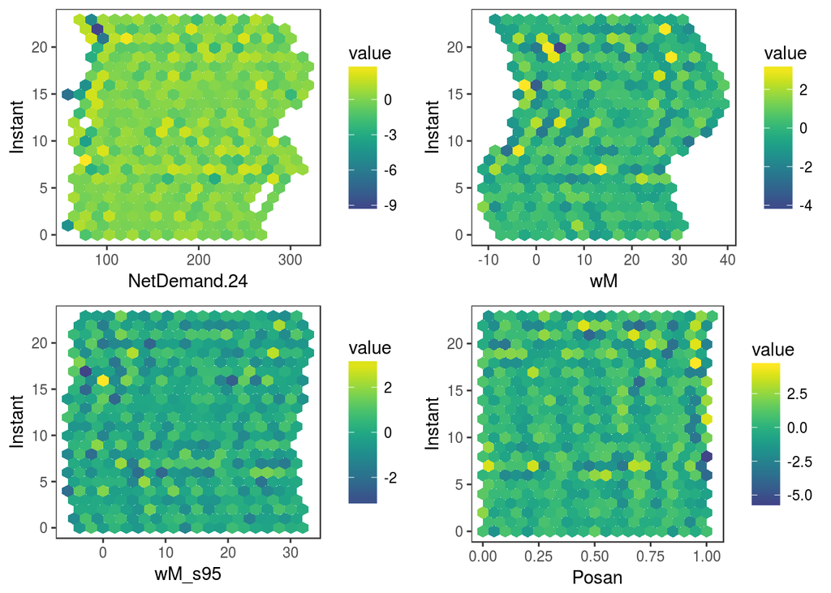

```r
pl <- lapply(c("NetDemand.24", "wM", "wM_s95", "Posan"),
             function(.nam){
               ( check2D(fit3, x1 = .nam, x2 = "Instant") + l_gridCheck2D() )$ggObj
             })

grid.arrange(grobs = pl, ncol = 2)
```

Good, the residual patterns are much less visible.

5. We start by plotting all the marginal effects on one page:

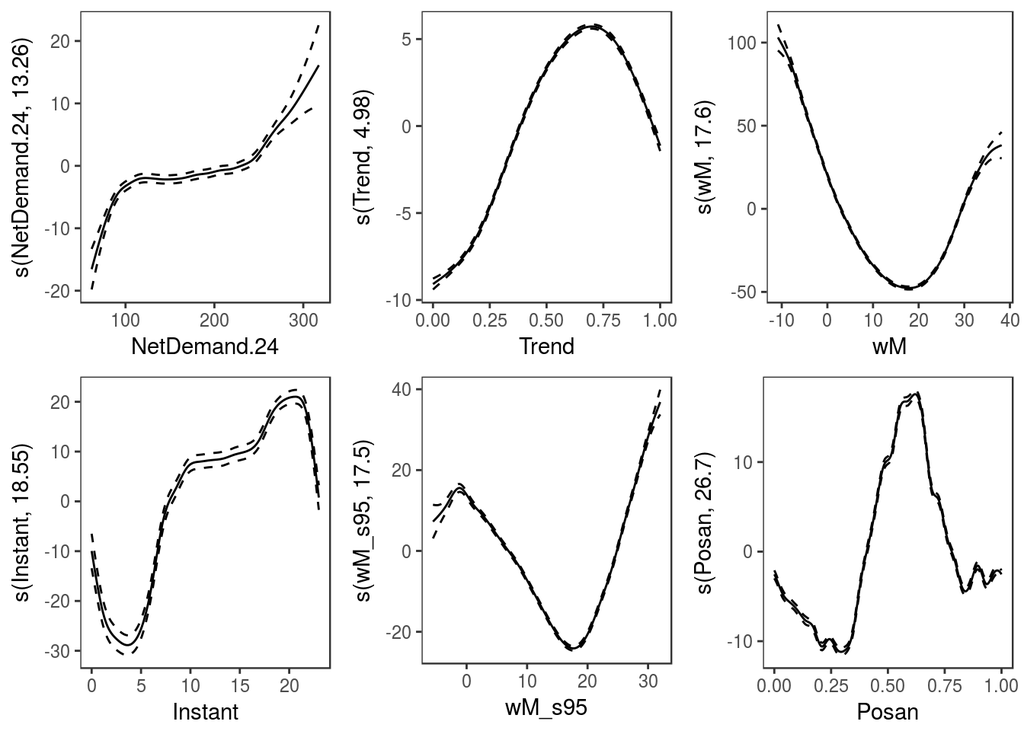

```r
print(plot(fit3, n = 200, select = 1:6), pages = 1)
```

Looks good, but one might want to have a closer look at what happens along `Posan`, which is quite wiggly. Maybe it is possible to do something better to taking into account the effect of holidays? Now we do the same with the 2D interactions:

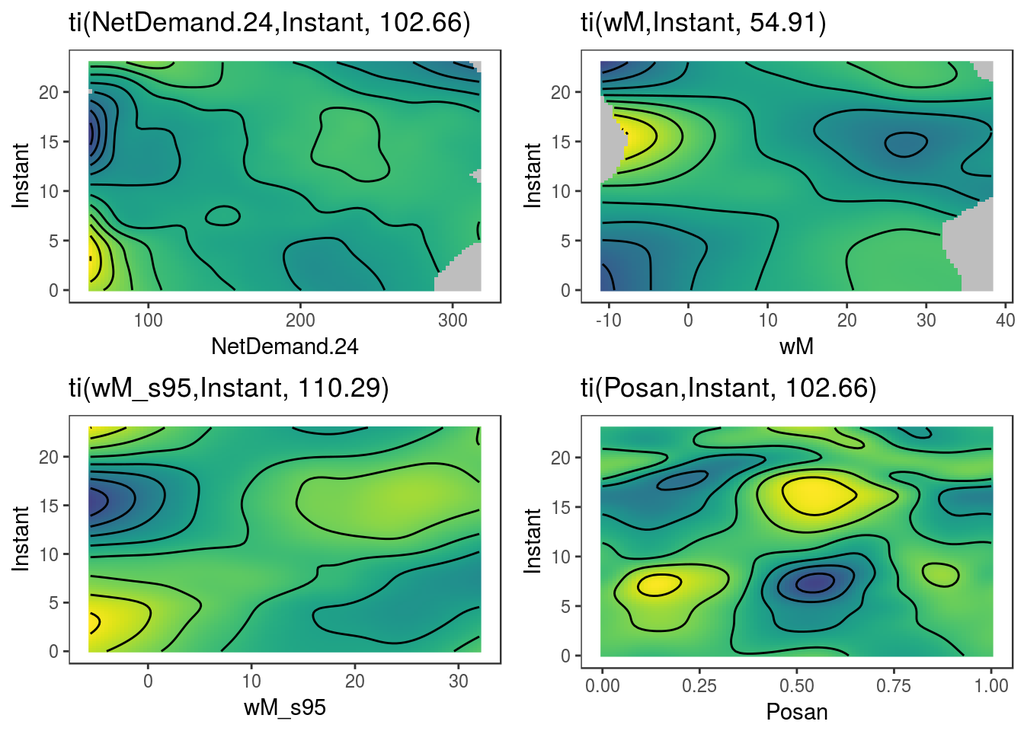

```r
print(plot(fit3, n2 = 100, select = 7:10) + theme(legend.position="none"),
      pages = 1)
```

Notice that we used `theme` to remove the legend. We now produce some customized plots:

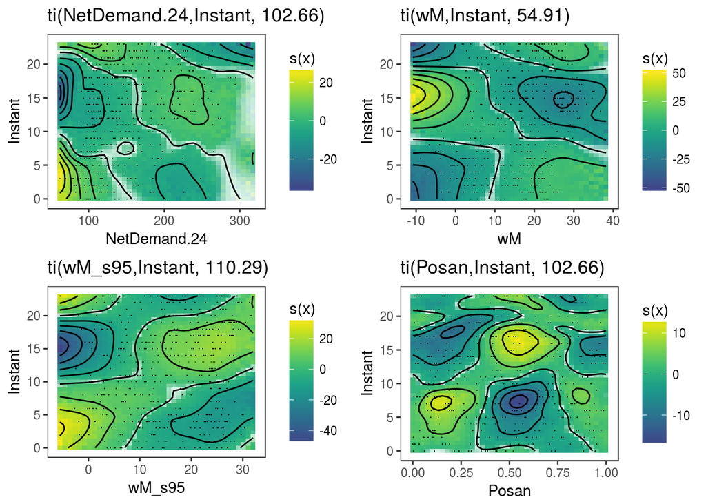

```r
pl <- lapply(7:10,
             function(.ii){
               ( plot(sm(fit3, .ii), too.far = -1, maxpo = 500) +
                 l_fitRaster(noiseup = T, pTrans = zto1(0.05, 3, 0.1)) +
                 l_fitContour() + l_points() )$ggObj
             })

grid.arrange(grobs = pl, ncol = 2)
```

Here we used `noiseup = TRUE` to add noise to the fitted surface, which gives an idea about the uncertainty in each effect. We also used `pTrans` to make so that the opacity of the heatmap is proportional to the statistical significance of the effect at each locations. We also set `too.far = -1` to avoid having grey areas far from design points, and we added a sub-sample of only 500 design points using `maxpo = 500`.

This code produces some RGL plots, which unfortunately will not appear in the html file:

```r
plotRGL(sm(fit3, 7), residuals = T)
clear3d()
plotRGL(sm(fit3, 8), residuals = T)
clear3d()
plotRGL(sm(fit3, 9), residuals = T)
clear3d()
plotRGL(sm(fit3, 10), residuals = T)
rgl.close()
```

6. We can look at the variance as follows

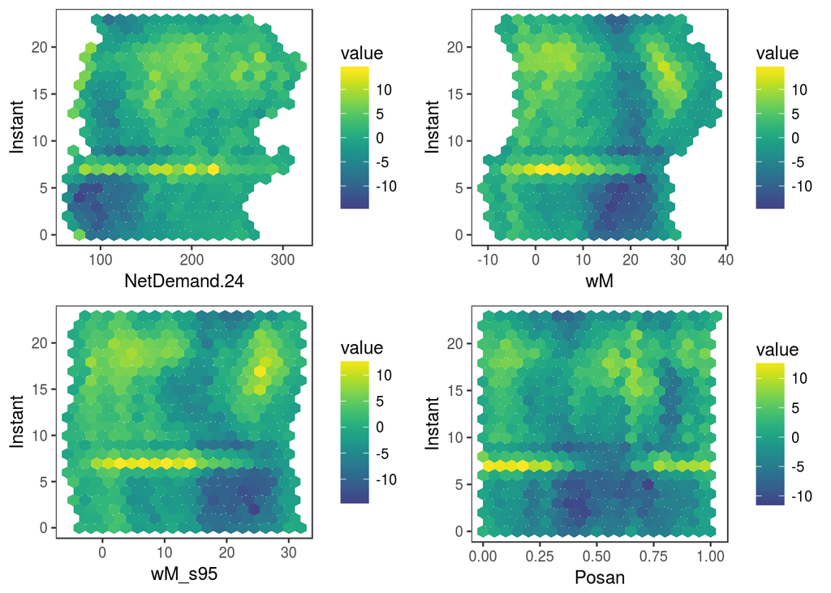

```r
pl <- lapply(c("NetDemand.24", "wM", "wM_s95", "Posan"),
             function(.nam){
               ( check2D(fit3, x1 = .nam, x2 = "Instant") +
                   l_gridCheck2D(gridFun = sd) )$ggObj
             })

grid.arrange(grobs = pl, ncol = 2)
```

The variance varies strongly along `Instant`, and it seems to peak around 8am (especially in the winter and at low temperatures). We do the same for skewness:

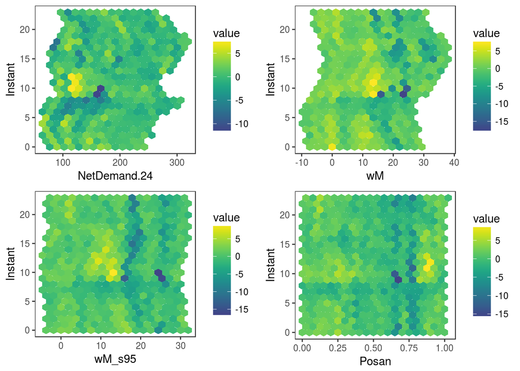

```r
library(e1071)
pl <- lapply(c("NetDemand.24", "wM", "wM_s95", "Posan"),
             function(.nam){
               ( check2D(fit3, x1 = .nam, x2 = "Instant") +
                   l_gridCheck2D(gridFun = skewness) )$ggObj
             })

grid.arrange(grobs = pl, ncol = 2)
```

It seems that the load distribution is positively skewed at night. We might be able to take this (and the variance) pattern into account using a GAMLSS model (e.g. usign the `gaulss` or `shash` families). But this would take longer to fit, because `bam` is unavailable for such models.